# Multifactor ANOVA, and visualization

Peter Ralph

15 October – Advanced Biological Statistics

# Outline

1. Permutation tests
2. Visualization
3. Means in many combinations of groups, i.e., multi-way ANOVA

# Permutation tests

```
##
##  Welch Two Sample t-test
##
## data:  airbnb$price[airbnb$instant_bookable] and airbnb$price[!airbnb$instant_bookable]
## t = 3.6482, df = 5039.8, p-value = 0.0002667
## alternative hypothesis: true difference in means is not equal to 0
## 95 percent confidence interval:
##   4.475555 14.872518
## sample estimates:
## mean of x mean of y
##  124.6409  114.9668
```

**But,** the $t$ test relies on *Normality*. Is the distribution of AirBnB prices too “wierd”? How can we be sure?

Methods:

1. Remove the big values and try again.
2. Use a nonparametric test.

## Remove the big values

(demonstration)

## The permutation test

*Observation:* **If** there was no meaningful difference in prices between “instant bookable” and not, **then randomly shuffling that label** won’t change anything.

Strategy:

1. Shuffle the `instant_bookable` column.
2. Compute the difference in means.
3. Repeat, many times.
4. Compare: the $p$-value is the proportion of “shuffled” values more extreme than observed.

[figure not shown]

*Why* is this a $p$-value? For what hypothesis?

## Shuffle once

```r
fake_is_instant <- sample(airbnb$instant_bookable)
(mean(airbnb$price[fake_is_instant], na.rm=TRUE) -
                mean(airbnb$price[!fake_is_instant], na.rm=TRUE))
```

```
## [1] 2.837541
```

## Many times

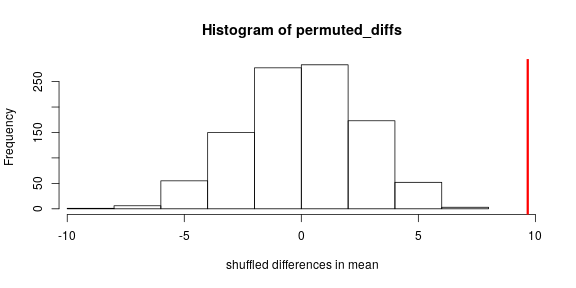

```r
real_diff <- (mean(airbnb$price[airbnb$instant_bookable], na.rm=TRUE) -
               mean(airbnb$price[!airbnb$instant_bookable], na.rm=TRUE))
permuted_diffs <- replicate(1000, {
        fake_is_instant <- sample(airbnb$instant_bookable)
        (mean(airbnb$price[fake_is_instant], na.rm=TRUE) -
               mean(airbnb$price[!fake_is_instant], na.rm=TRUE))
   } )
hist(permuted_diffs, xlab="shuffled differences in mean", xlim=range(c(permuted_diffs, real_diff)))
abline(v=real_diff, col='red', lwd=3)
```

## How surprising was the real value?

```r
mean(abs(permuted_diffs) > abs(real_diff))
```

```
## [1] 0
```

> The difference in price between instant bookable and not instant bookable is highly statistically significant ($p \approx 0.001$, permutation test).

## Your turn

Do the analogous thing for the ANOVA comparing price between neighbourhoods:

```r
anova(lm(price ~ neighbourhood, data=airbnb))
```

```
## Analysis of Variance Table
##
## Response: price
##                 Df   Sum Sq Mean Sq F value    Pr(>F)
## neighbourhood   91  6015248   66102  7.6277 < 2.2e-16 ***
## Residuals     5510 47749952    8666
## ---
## Signif. codes:  0 '***' 0.001 '**' 0.01 '*' 0.05 '.' 0.1 ' ' 1
```

## in class

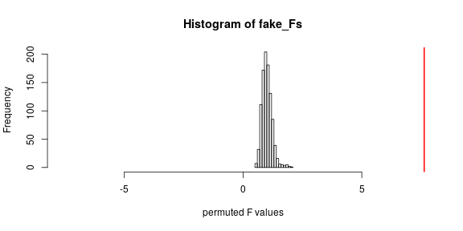

```r
true_F <- anova(lm(price ~ neighbourhood, data=airbnb))[["F value"]][1]

# do this a lot of times:
## DO NOT put the randomness here: fake_neighbourhood <- sample(airbnb$neighbourhood)
fake_Fs <- replicate(1000, {
    fake_neighbourhood <- sample(airbnb$neighbourhood)  # randomness must be here
    anova(lm(price ~ fake_neighbourhood, data=airbnb))[["F value"]][1]
   })
hist(fake_Fs, xlim=range(fake_Fs, c(-1,1)*true_F), xlab="permuted F values")
abline(v=true_F, col='red', lwd=2)
```

# Visualization

## Goals

- pattern discovery
- efficient summary of information
- visual/spatial analogy for quantitative patterns

aim to *maximize information and minimize ink*

paraphrased from Edward Tufte

## Considerations

- Is the visual analogy appropriate for the *type* of data?

counts? quantities? multivariate? relationships?

- Are important *comparisons* clear?

between groups? differences? time trend?

- Are *units* easily interpretable?

meters? dollars? percent? relative change? is it isometric?

## Principles of effective display

- Show the data
- Encourage the eye to compare differences
- Represent magnitudes honestly and accurately
- Draw graphical elements clearly, minimizing clutter
- Make displays easy to interpret

> Above all else show the data.

Tufte 1983

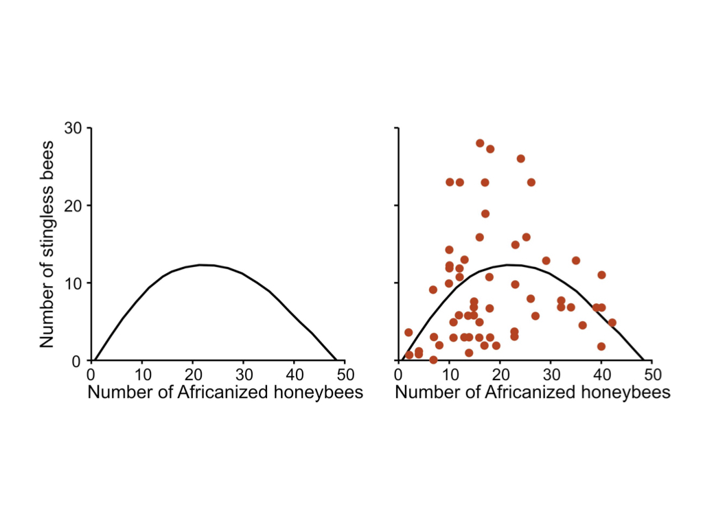

honeybees

## Case study:

Distributions of litter sizes by Order, and Family, in the PanTHERIA dataset:

```r
pantheria <- read_pantheria("../Datasets/PanTHERIA")
# look at most common orders
order_nums <- sort(table(pantheria$Order))
big_orders <- names(order_nums)[order_nums > 150]
```

```
##
##   Microbiotheria    Tubulidentata       Dermoptera Notoryctemorphia
##                1                1                2                2
##      Proboscidea       Hyracoidea      Monotremata          Sirenia
##                3                4                5                5
## Paucituberculata        Pholidota           Pilosa    Macroscelidea
##                6                8               10               15
##   Perissodactyla       Scandentia        Cingulata  Peramelemorphia
##               17               20               21               21
##   Erinaceomorpha     Afrosoricida   Dasyuromorphia          Cetacea
##               24               51               71               84
##  Didelphimorphia       Lagomorpha    Diprotodontia     Artiodactyla
##               87               92              143              240
##        Carnivora         Primates     Soricomorpha       Chiroptera
##              286              376              428             1116
##         Rodentia
##             2277
```

## note the pipe

```r
px <- (pantheria %>% filter(Order %in% big_orders)
       %>% filter(!is.na(LitterSize))
       %>% select(Order, Family, Genus, Species, LitterSize))
for (xn in c("Order", "Family", "Genus")) px[[xn]] <- factor(px[[xn]])
summary(px)
```

```
##           Order                  Family              Genus
##  Artiodactyla:178   Muridae         : 242   Microtus    :  38
##  Carnivora   :209   Cricetidae      : 239   Myotis      :  38
##  Chiroptera  :465   Sciuridae       : 158   Crocidura   :  36
##  Primates    :209   Vespertilionidae: 135   Peromyscus  :  32
##  Rodentia    :883   Bovidae         : 110   Sorex       :  32
##  Soricomorpha:116   Phyllostomidae  : 106   Spermophilus:  31
##                     (Other)         :1070   (Other)     :1853
##    Species            LitterSize
##  Length:2060        Min.   : 0.960
##  Class :character   1st Qu.: 1.000
##  Mode  :character   Median : 1.970
##                     Mean   : 2.489
##                     3rd Qu.: 3.490
##                     Max.   :11.300
##
```

## Raw numbers

```r
px$LitterSize
```

```
##    [1]  0.98  4.50  3.74  5.72  4.98  1.22  1.00  1.22  1.01  1.02  1.02
##   [12]  1.02  1.02  1.39  1.39  3.89  2.00  1.09  1.73  1.45  1.11  1.02
##   [23]  1.01  1.01  1.00  1.01  1.02  1.02  1.01  1.01  1.05  1.84  2.00
##   [34]  2.00  2.00  2.31  2.00  2.00  1.93  1.04  1.94  3.00  2.19  1.94
##   [45]  2.36  2.62  3.00  1.29  4.91  5.30  4.29  6.27  4.00  4.99  1.50
##   [56]  1.50  2.00  3.40  1.01  1.02  1.01  2.00  1.22  1.00  1.73  1.00
##   [67]  0.99  1.00  7.29  6.12  1.00  1.00  1.00  1.00  1.00  1.01  1.01
##   [78]  1.01  1.02  1.01  1.02  1.01  1.02  1.01  1.02  1.02  1.02  1.00
##   [89]  1.00  1.00  1.02  1.00  1.02  1.01  1.02  1.02  1.01  1.02  3.09
##  [100]  1.09  1.00  1.00  0.99  1.00  0.99  2.91  3.68  4.00  3.45  5.28
##  [111]  5.34  5.53  3.46  3.40  3.50  6.06  5.71  5.20  7.14  3.99  0.99
##  [122]  2.99  2.99  3.00  3.59  4.29  1.99  3.37  1.99  1.73  3.74  3.00
##  [133]  2.99  3.89  3.00  2.44  4.04  3.99  3.49  1.22  1.50  4.86  1.00
##  [144]  1.00  1.00  1.01  1.50  2.50  2.29  2.12  0.96  0.98  1.00  3.40
##  [155]  5.39  3.95  2.62  2.52  1.21  0.98  1.00  0.98  1.02  1.00  1.00
```

[output cut: 173 more lines]

## stem-and-leaf “plot”

```r
stem(px$LitterSize)
```

```
##
##   The decimal point is at the |
##
##    0 |
##    1 | 00000000000000000000000000000000000000000000000000000000000000000000+937
##    2 | 00000000000000000000000000000000000000000000000000000000000000000000+259
##    3 | 00000000000000000000000000000000000000000000000000000000000000000000+230
##    4 | 00000000000000000000000000000000000000000011111111122222222222222233+103
##    5 | 00000000000000000000000000000111111222222222222223333333333333444444+35
##    6 | 00000000000111122223333444455555555666777788899999
##    7 | 001111235555567888899
##    8 | 000011155557789
##    9 | 0000249
##   10 | 0
##   11 | 23
```

## five(-ish) number summary

```r
summary(px$LitterSize)
```

```
##    Min. 1st Qu.  Median    Mean 3rd Qu.    Max.
##   0.960   1.000   1.970   2.489   3.490  11.300
```

## Points

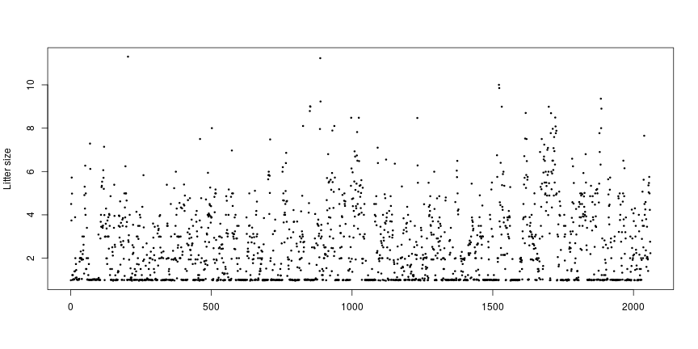

```r
plot(px$LitterSize, xlab='', ylab='Litter size', pch=20, cex=0.5)
```

## Points, sorted

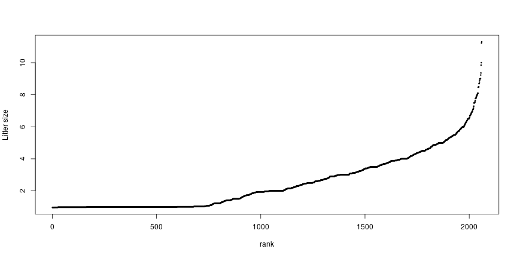

```r
plot(sort(px$LitterSize), xlab='rank', ylab='Litter size', pch=20, cex=0.5)
```

## Points, sorted and colored

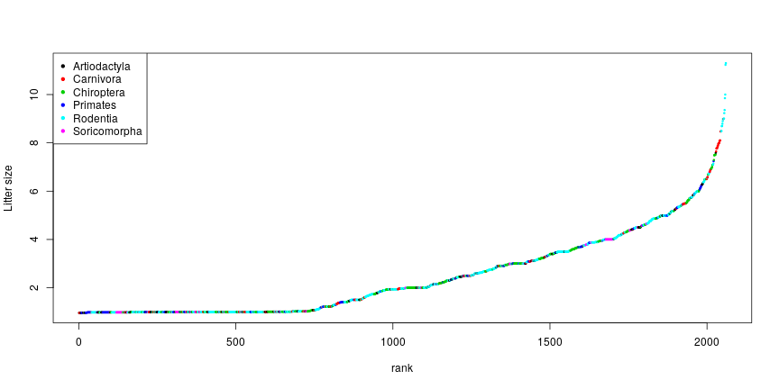

```r
plot(sort(px$LitterSize), col=px$Order, xlab='rank', ylab='Litter size', pch=20, cex=0.5)
legend("topleft", pch=20, col=1:nlevels(px$Order), legend=levels(px$Order))
```

## Histogram

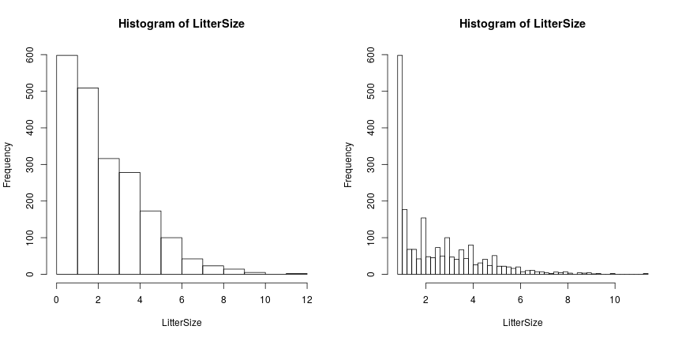

```r
layout(t(1:2))
with(px, hist(LitterSize))
with(px, hist(LitterSize, breaks=40))
```

## Histograms

```r
layout(matrix(1:6, ncol=3, byrow=TRUE), heights=c(1, 1.2))
opar <- par(mar=c(1, 3, 1, 1)+.1)
xh <- hist(px$LitterSize, plot=FALSE, breaks=30)
for (k in 1:nlevels(px$Order)) {
    ord <- levels(px$Order)[k]
    if (k == 4) par(opar)
    with(subset(px, Order == ord),
        hist(LitterSize, xlim=c(0, max(px$LitterSize)),
             breaks=xh$breaks, main=ord,
             xaxt=if (k > 3) 's' else 'n',
             xlab=if (k > 3) 'litter size' else '') )
}
```

## Histograms

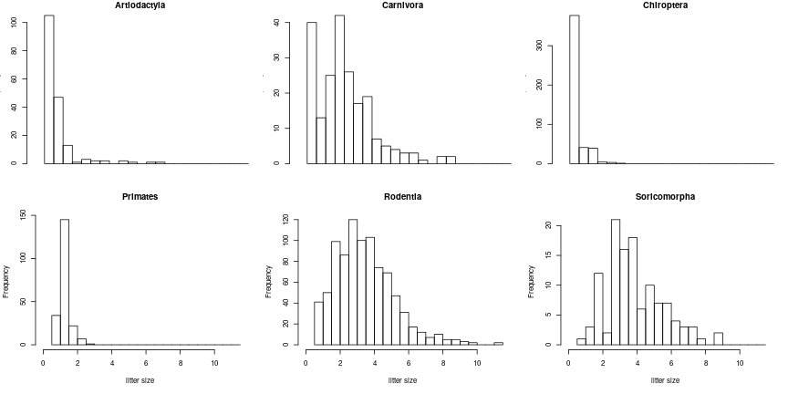

## Overlaid histograms

```r
overlay_hist <- function (x, f, breaks=30, ...) {
    xh <- hist(x, breaks=breaks, plot=FALSE)
    ymax <- do.call(max, with(px, lapply(tapply(LitterSize, Order, hist, plot=FALSE), "[[", "counts")))
    for (k in 1:nlevels(f)) {
        hist(x[f==levels(f)[k]], breaks=xh$breaks, ...,
             add=(k>1), col=adjustcolor(k, 0.4), ylim=c(0, ymax))
    }
    legend("topright", fill=adjustcolor(1:nlevels(f), 0.4),
           legend=levels(f))
}
```

## Overlaid histograms

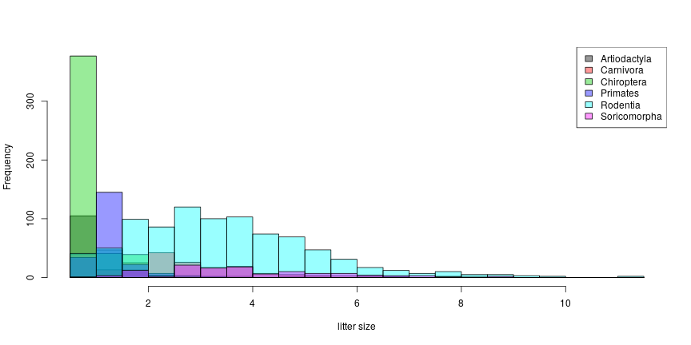

```r
with(px, overlay_hist(LitterSize, Order, xlab='litter size', main=''))
```

## boxplots

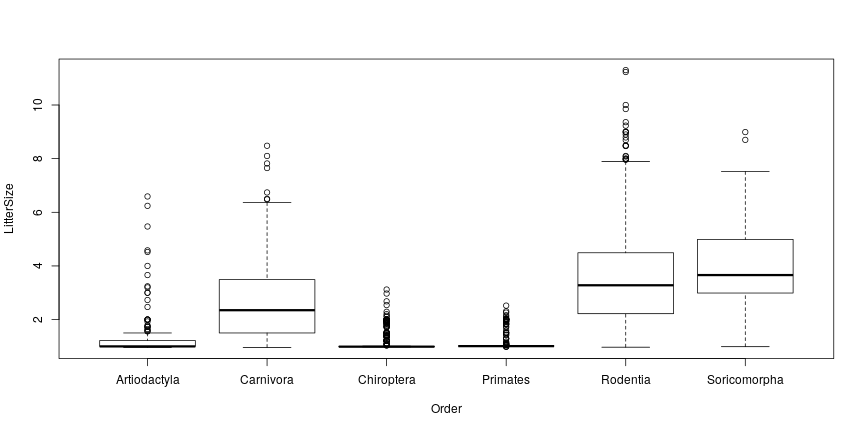

introduced by [Mary Eleanor Spear](https://en.wikipedia.org/wiki/Mary_Eleanor_Spear)

```r
with(px, boxplot(LitterSize ~ Order))
```

## Many boxes

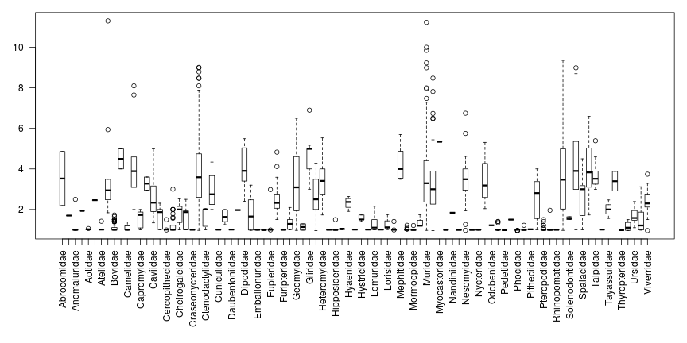

```r
par(mar=c(9, 3, 1, 1) + 0.1)
with(px, boxplot(LitterSize ~ Family, las=2, xlab=''))
```

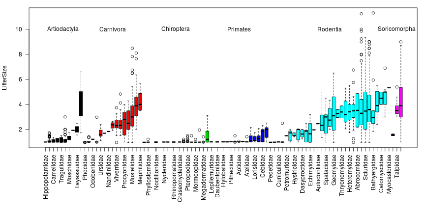

```r
par(mar=c(9, 4, 1, 1) + 0.1)
famsize <- aggregate(LitterSize ~ Order + Family, data=px, mean)
famorder <- rank(with(famsize, LitterSize + 100 * as.numeric(Order)))
with(px, boxplot(LitterSize ~ Family, las=2, xlab='',
                 col=as.numeric(famsize$Order),
                 at=famorder))
text(x=tapply(famorder, famsize$Order, mean),
     y=10, label=levels(famsize$Order))
```

## Your turn

*Challenge:* visualize `LitterSize` by `TeatNumber`, using a boxplot.

# The Grammar of Graphics

## or, “`gg`”

- introduced by [Leland Wilkinson](https://www.springer.com/gp/book/9780387245447)
- adopted by [Hadley Wickham](http://hadley.nz/) in the `ggplot` library
- thinks of plots as *objects*
- see [this chapter](https://r4ds.had.co.nz/data-visualisation.html) of *R for Data Science*

## Ingredients of a visualization

- data
- coordinate axes
- a `geom`etric representation of numbers
- a mapping from (summaries of) variables to properties of the geoms
- maybe more plots

## basic template

```r
ggplot(data = <DATA>) +
  <GEOM_FUNCTION>(mapping = aes(<MAPPINGS>))
```

## more options

```r
ggplot(data = <DATA>) +
  <GEOM_FUNCTION>(
     mapping = aes(<MAPPINGS>),
     stat = <STAT>,
     position = <POSITION>
  ) +
  <COORDINATE_FUNCTION> +
  <FACET_FUNCTION>
```

*Reference:* the [ggplot2 book](https://ggplot2-book.org/index.html).

## Points

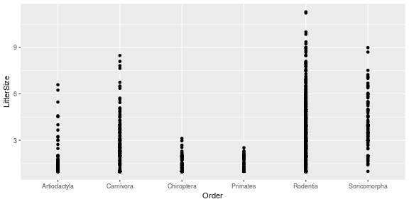

```r
ggplot(px, mapping=aes(x=Order, y=LitterSize)) + geom_point()
```

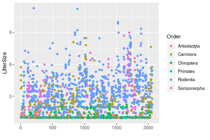

```r
(ggplot(px,
        mapping=aes(x=1:nrow(px),
                    y=LitterSize,
                    col=Order))
 + xlab("")
 + geom_point())
```

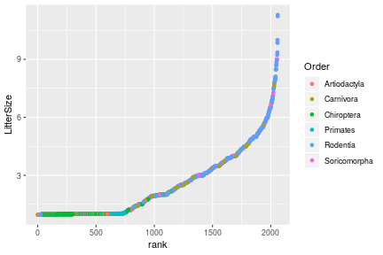

```r
(ggplot(px,
        mapping=aes(x=rank(LitterSize,
                           ties.method='first'),
                    y=LitterSize,
                    col=Order))
 + xlab("rank")
 + geom_point())
```

## Histogram

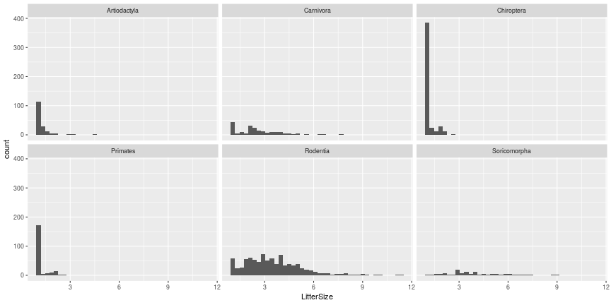

```r
ggplot(px, mapping=aes(LitterSize)) + geom_histogram(bins=40) + facet_wrap(~ Order)
```

## Histogram, stacked

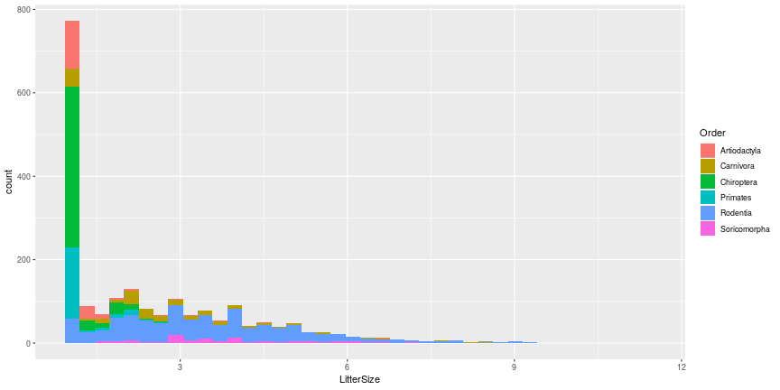

```r
ggplot(px, mapping=aes(LitterSize, fill=Order)) + geom_histogram(bins=40)
```

## Boxplot

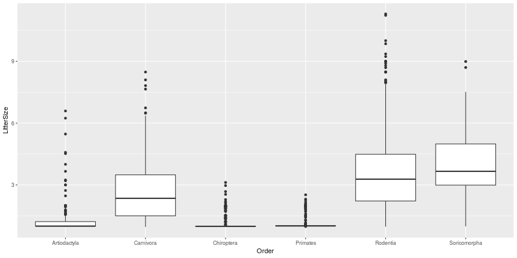

```r
ggplot(px, mapping=aes(y=LitterSize, x=Order)) + geom_boxplot()
```

## Your turn, again

*Challenge:* make this plot.

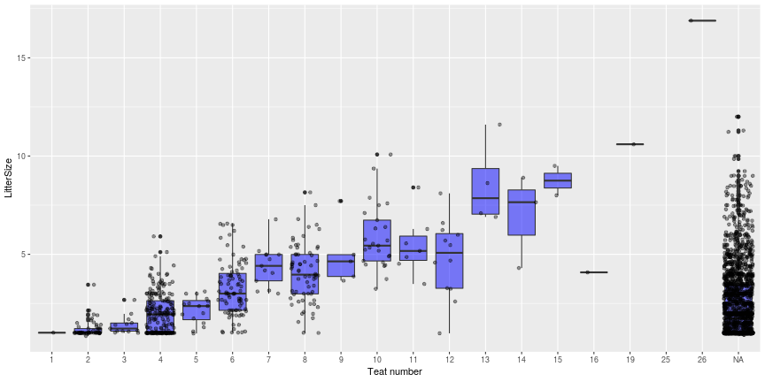

The [cheatsheet](https://rstudio.com/wp-content/uploads/2015/03/ggplot2-cheatsheet.pdf) might be helpful.